# R Notebook - Melbourne House Snapshot, EDA

Simple Exploratory data analysis Melbourne House Snapshot

## Introduction and Context

Simple EDA Melbourne House Snapshot. O objetivo é realizar uma exploração de dados no dataset “Melbourne House Snapshot” e aplicar um modelo para prever a feature “Price” tendo como base várias outras features representando características do imóvel.

Caractéristicas identificadas (Dicionário):

- Address: Endereço
- Suburb: Subúrbio/Periféria
- PostCod: Código postal
- YearBuild: Ano de construção
- Rooms: Número de quartos;
- Price: Preço do imóvel em Dollar.
- Method: Metodo de venda, sendo:  
  S - imóvel vendido; SP - imóvel vendido anteriormente; PI - propriedade transmitida; PN - vendido antes não divulgado; SN - vendido não divulgado; NB - sem licitação; VB - oferta do fornecedor; W - retirado antes do leilão; SA - vendido após leilão; SS - vendido após o preço do leilão não divulgado. N / A - preço ou lance mais alto não disponível.
- Type: Tipo do imóvel, sendo: br - quarto (s); h - casa, casa de campo, villa, semi, terraço; unidade, duplex - casa geminada; site dev - site de desenvolvimento; o res - outro residencial.
- VendedorG: Agente imobiliário.
- Date: Data de venda.
- Distance: Distância, provavelmente em milhas, CBD (Central Business District) distrito central de negócios.
- Regionname: Região Geral (West, North West, North, North east …etc)
- Propertycount: Número de propriedades que existem no súrbubio/periferia.
- Bedroom2: Representa “Rooms”, mas obtido de outra fonte.
- Bathroom: Número de banheiros.
- Car: Número de vagas de estácionamento.
- Landsize: Tamanho do terreno.
- BuildingArea: Tamanho da construção.
- ConcilArea: Governing council for the area
- Propertycount: Ainda não identificado.
- Longtitude: Longitude
- Lattitude: Latitude

## Overview and Data Pre-processing

### Load Libraries

```r
library(tidyverse) # Geral EDA
library(rpart) # Regression Tree
library(modelr) # mae function: sqrt((actual-predicted)²)
library(ggplot2) # Geral plot
library(dplyr) # Use %>%
```

### Load Data

```r
#importing data
melbourne <- read.csv("./data/melb_data.csv", stringsAsFactors = FALSE)
```

### Overview

```r
str(melbourne)
```

[output not shown]

```r
colSums(is.na(melbourne))
```

```
       Suburb       Address         Rooms          Type         Price        Method       SellerG
            0             0             0             0             0             0             0
         Date      Distance      Postcode      Bedroom2      Bathroom           Car      Landsize
            0             0             0             0             0            62             0
 BuildingArea     YearBuilt   CouncilArea     Lattitude    Longtitude    Regionname Propertycount
         6450          5375             0             0             0             0             0
```

Valores NA de cada atributo do conjunto de dados.

- Colunas Car, BuldingArea e YearBuilt apresentam problemas quanto a valores NA, sendo as duas últimas mais problematicas por apresentarem grande quantidade de valores NA.

```r
round(sum(is.na(melbourne$BuildingArea))/length(melbourne$BuildingArea)*100, digits=2)
round(sum(is.na(melbourne$YearBuilt))/length(melbourne$YearBuilt)*100, digits=2)
```

- BuildingArea e YearBuilt apresentam respectivamente 47.5% e 39.58% de valores NA.

## Análise univariada

### Suburb Column

```r
suburb_t <- round(prop.table(table(melbourne$Suburb)), digits=3)*100
max(suburb_t)
```

```
[1] 2.6
```

- Como visto anteriormente, a coluna “Suburb” possui 314 levels, acima podemos ver que o valor que mais se repete nessa coluna ocorre 2.6% das vezes, não representando um valor que ocorre com frequência.
- Abaixo plotamos um histograma desses valores, a maior parte dos valores em “Suburb” ocorre, em termos relativos, 0% das vezes, ou seja, ocorre pouquissimas vezes.

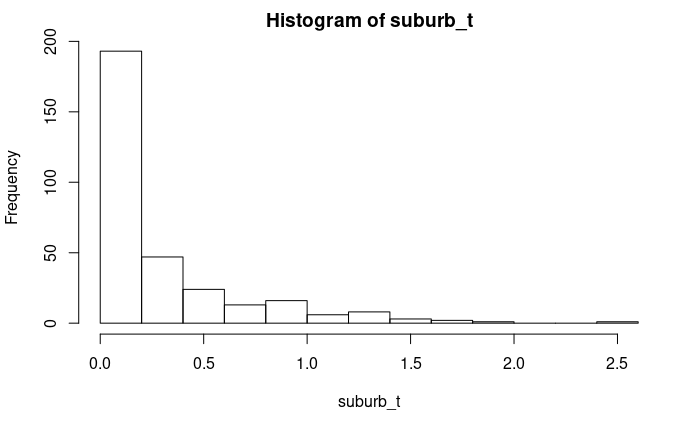

```r
hist(suburb_t)
```

- Os valores que mais ocorrem e sua frequência absoluta são mostrados abaixo.

```r
summary(melbourne$Suburb)
```

```
         Reservoir           Richmond     Bentleigh East            Preston          Brunswick
               359                260                249                239                222
          Essendon        South Yarra          Glen Iris           Hawthorn             Coburg
               220                202                195                191                190
         Northcote           Brighton                Kew       Balwyn North        Pascoe Vale
               188                186                177                171                171
        Yarraville           St Kilda            Glenroy     Port Melbourne       Moonee Ponds
               164                162                159                153                149
          Carnegie          Bentleigh          Thornbury      Brighton East            Newport
               146                139                139                138                137
        Camberwell          Footscray             Elwood         Ascot Vale            Hampton
               132                132                131                130                130
      Surrey Hills            Prahran        Keilor East      Hawthorn East         Kensington
               125                123                121                119                117
      Malvern East          Doncaster           Sunshine     Brunswick West             Balwyn
               117                116                111                110                107
      Williamstown     West Footscray            Fawkner             Toorak            Ivanhoe
               107                105                102                100                 98
       Maribyrnong           Armadale          Maidstone      Fitzroy North  Templestowe Lower
                96                 95                 94                 93                 92
    Brunswick East      Sunshine West    South Melbourne            Burwood             Ormond
                88                 86                 85                 84                 83
       Murrumbeena            Niddrie    North Melbourne Heidelberg Heights    Heidelberg West
                82                 82                 81                 78                 76
            Altona   Avondale Heights            Bulleen        Albert Park     Sunshine North
                74                 74                 71                 69                 68
      Airport West            Malvern        Collingwood          Moorabbin           Oak Park
                67                 67                 65                 64                 63
        Strathmore         Flemington           Hadfield             Seddon        Elsternwick
                63                 62                 62                 62                 61
           Rosanna          Ashburton            Windsor           Box Hill            Fitzroy
                61                 60                 60                 59                 59
    Oakleigh South       Clifton Hill     Mount Waverley         Abbotsford       Altona North
                58                 57                 57                 56                 56
      Coburg North         Canterbury             Epping           Watsonia            Carlton
                56                 54                 52                 52                 51
        Heidelberg           Werribee           Kew East      Carlton North    Caulfield South
                51                 50                 49                 48                 47
       Craigieburn           Oakleigh            Ashwood          Braybrook            (Other)
                47                 47                 46                 46               2975
```

### Adress Column

- Como observado acima, quase nenhum valor em “Adress” se repete. Uma coisa interessante seria observar os valores que ocorrem mais de uma vez.

```r
summary(melbourne$Address)
```

```
      1/1 Clarendon St         13 Robinson St           14 Arthur St             2 Bruce St
                     3                      3                      3                      3
           28 Blair St       36 Aberfeldie St           5 Charles St          5 Margaret St
                     3                      3                      3                      3
         53 William St         1 Bellarine St             1 Daisy St     1/108 Truganini Rd
                     3                      2                      2                      2
      1/12 Hatfield Ct         1/16 Mawbey St        1/16 Osborne Av           1/26 York St
                     2                      2                      2                      2
        1/44 Arthur St            10 Beryl St        10/2 Howlett St        101 The Fairway
                     2                      2                      2                      2
       103 Pleasant Rd           11 Church St            11 Duffy St          11 Kerferd St
                     2                      2                      2                      2
          11 Murphy St       11 Nottingham St          11 Vincent St           11 Wilson St
                     2                      2                      2                      2
        112 Belmore Rd       118 Westgarth St            119 Park St           12 Gordon St
```

[output cut: 35 more lines]

```r
summary(melbourne$Price)
```

```
   Min. 1st Qu.  Median    Mean 3rd Qu.    Max.
  85000  650000  903000 1075684 1330000 9000000
```

```r
temp <- melbourne[Price <= 9000000]
```

```
Error in `[.data.frame`(melbourne, Price <= 9e+06) :
  object 'Price' not found
```

```r
#install.packages("data.table")
library(data.table)

melb <- data.table::fread('./data/melb_data.csv', na.strings = "", stringsAsFactors = TRUE)
```

[output not shown]

```r
round(prop.table(table(melbourne$Type))*100, digits = 2)
round(prop.table(table(melbourne$Method))*100, digits = 2)
```

```r
#typeof(melbourne$Type)
```

### Overview - Plotagens

```r
ggplot(melbourne, aes(x=Rooms, y=Price, color=Type)) + geom_point()
ggplot(melbourne, aes(x=Landsize, y=Price)) + geom_point()
ggplot(melbourne, aes(x=YearBuilt, y=Price)) + geom_point()
ggplot(melbourne, aes(x=BuildingArea, y=Price)) + geom_point()
ggplot(melbourne, aes(x=Car, y=Price, color=Method)) + geom_point()
ggplot(melbourne, aes(x=Lattitude, y=Price, color=Regionname)) + geom_point()
ggplot(melbourne, aes(x=Longtitude, y=Price, color=Regionname)) + geom_point()
ggplot(melbourne, aes(x=Postcode, y=Price, color=Regionname)) + geom_point()
ggplot(melbourne, aes(x=Lattitude, y=Price, color=Rooms)) + geom_point()
ggplot(melbourne, aes(x=Lattitude, y=Longtitude, color=Regionname, alpha=0.5)) + geom_point()
ggplot(melbourne, aes(x=Distance, y=Price)) + geom_point()
ggplot(melbourne, aes(x=Rooms, y=Price, color=Regionname)) + geom_point()
```

[output not shown]

```r
dim(melbourne %>% count(Postcode))
dim(melbourne %>% count(Address))
```

```r
#Aplicando rápida Regression Tree

fit_regTree <- rpart(Price ~ Rooms +  Lattitude + Longtitude, data=melbourne)
plot(fit_regTree, uniform = TRUE); text(fit_regTree, cex=0.9)
round(mae(model=fit_regTree, data=melbourne), digits = 2)
```

```r
summary(fit_regTree)
```

## Some references

[1]https://sebastiansauer.github.io/figure_sizing_knitr/